# PG2 : Zonas de estudio y el desempeño académico

05 Mayo, 2023

# 1 Introducción

El tiempo que pasan los estudiantes en las zonas de estudio de la universidad(piso 1, piso 6, biblioteca y salones vacíos)

## 1.1 Relevancia

Dado el caso de la semipresencialidad y la presencialidad del ciclo pasado y el actual, nos hemos visto en la necesidad de realizar la ruta normal de nuestros hogares, hasta la universidad. Entonces muchos estudiantes deciden realizar sus actividades de estudio, avance de proyectos, tareas y productividad en general en las zonas o espacios de estudio que brinda la universidad. Nuestro objetivo es poder demostrar, comprobar o averiguar si hay una influencia directa positiva o negativa en el uso de los espacios de estudio de la universidad, para con los estudiantes y su desempeño académico.

## 1.2 Planificación

En el siguiente diagrama se mostrará el orden de las actividades que se realizaron durante estas primeras semanas del semestre, en el cual se señalará cada actividad con su respectivo tiempo de avance.

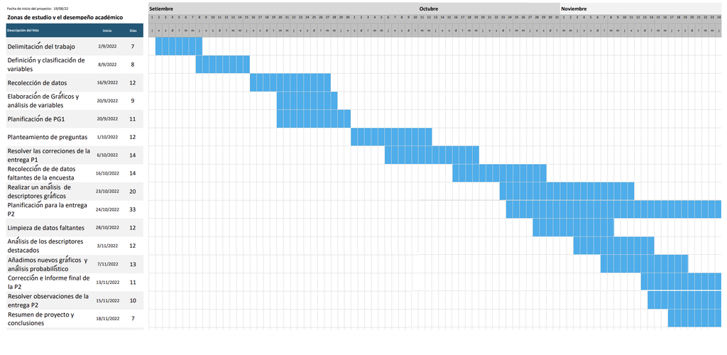

# 2 Datos

## 2.1 Recolección de datos

El objetivo de nuestro estudio es observar si los espacios de estudio de la universidad afecta de alguna manera al desempeño académico de los estudiantes. En base a nuestro objetivo se optó por la realización de una encuesta en Google Forms, en la cual se podría obtener información valiosa de cada estudiante respecto a su desempeño y a las variables relacionadas con los espacios de estudio de la universidad.

En principio se ejecutó una reunión y se establecieron las variables necesarias para el estudio, posteriormente se crearon las limitaciones de las variables en donde fuera necesario; luego, se colocaron ejemplos de la respuesta esperada en algunos ítems para un mejor entendimiento y facilitar la respuesta del encuestado. Finalmente, el equipo realizó una última revisión y se pasó a compartir la encuesta por redes sociales y también se aplicó de manera presencial. Cabe especificar que en ambos casos se llenó el mismo formulario. Además, se trató de recolectar las respuestas de universitarios de segundo ciclo en adelante (dado que ellos ya cuenta con una variable que describe su desempeño académico) y que asistieron de manera híbrida y presencial en la situación actual.

## 2.3 Variables

Nuestra base de datos contiene 19 variables de interés para el estudio, de las cuales 6 son Cualitativas nominales, 2 Cualitativas ordinales, 7 Numéricas discretas y 1 Numérica continua.

| Variables | Descripción de la variable | Tipo de variable | Restricción |
| --- | --- | --- | --- |
| Sexo | Sexo del estudiante | Categórica nominal | No hubo restricción |
| Edad | Edad del estudiante | Numérica discreta | No hubo restricción |
| Carrera | Carrera de los estudiantes | Categórica nominal | No hubo restricción |
| Distrito | Zona de donde procede el estudiante | Categórica nominal | Sólo para estudiantes con residencia en Lima Metropolitana |
| Ciclo | Ciclo del estudiante | Categórica ordinal | Se tomó en cuenta a los de primer ciclo, pero se eliminó su variable promedio |
| Hora_prom_Uni | Tiempo que promedio que están en la universidad por semana | Numérica discreta | Ingresar la cantidad en horas(valor entero más cercano) |
| Hora_prom_ZonaEst | Tiempo promedio que se la pasa en las zonas de estudio de la universidad | Numérica discreta | Ingresar la cantidad en horas(valor entero más cercano) |
| Hora_prom_Est | Horas de estudio semanales, sin contar las horas de clase | Numérica discreta | Ingresar la cantidad en horas(valor entero más cercano) |
| Promedio_Ponderado | Promedio de que obtuvo durante el ciclo anterior | Numérica continua | Ingresar valores entre 0 y 20 |
| EspacioEst_habitual | Espacio de estudio en el que normalmente pasa más tiempo | Categórica nominal | Decide entre los espacios de estudio, piso 6, piso 1, etc |
| Afecta_Posi_Nega | Cómo percibe que afecta estas zonas de estudio en su ámbito académico | Categorica nominal | Binario (Positivamente o Negativamente) |
| Uso_Lugar_Estudio | Para qué usa el estudiante los espacios de estudio | Categórica nominal | Decide si usa los espacios de estudio para avanzar tareas, proyectos, estudiar, etc |
| Hora_prom_Biblioteca | Horas promedio a la semana que está en la biblioteca | Numérica discreta | Ingresar en horas |
| Hora_prom_Piso1 | Horas promedio a la semana que está en el piso 1 | Numérica discreta | Ingresar en horas |
| Hora_prom_piso6 | Horas promedio a la semana que está en la piso 6 | Numérica discreta | Ingresar en horas |
| Preferencia | Qué zona de estudio es preferida por los estudiantes, seguido de las demás en orden | Categórica ordinal | En orden de preferencia entre las zonas de estudio |

## 2.4 Limpieza de base de datos

Lo primero que haremos es cargar las librerías que se emplearán para este proyecto, luego la encuesta que previamente descargamos en nuestro directorio de trabajo. Lo siguiente será renombrar las variables para tener un mejor manejo de ellas, eliminamos las variables que no utilizaremos para esta investigación, como por ejemplo “Marca temporal” y “En base a la pregunta anterior, ¿Por qué?”. Limpiamos cada variable de los errores ortográficos que hay a la hora de pedir que ingresen una respuesta en la encuesta, también borramos lo datos atípicos de alguna variable, como puede ser en la variable promedio ponderado con el valor de 0 , ya que significaría que el alumno estaba ausente durante todo el ciclo o es de primer ciclo. Finalmente, le cambiamos de nombre a nuestra base de datos limpia obteniendo lo siguiente:

```r
dfn <- df # base de datos limpia

summary(dfn)
```

```
##      Sexo                Edad         Carrera            Distrito
##  Length:250         Min.   :11.00   Length:250         Length:250
##  Class :character   1st Qu.:18.00   Class :character   Class :character
##  Mode  :character   Median :19.00   Mode  :character   Mode  :character
##                     Mean   :19.58
##                     3rd Qu.:21.00
##                     Max.   :25.00
##
##      Ciclo    Hora_prom_Uni   Hora_prom_ZonaEst Hora_prom_Est
##  3º     :51   Min.   : 3.00   Min.   : 0.00     Min.   : 1.00
##  2º     :48   1st Qu.:12.00   1st Qu.: 4.00     1st Qu.: 6.00
##  4º     :39   Median :23.00   Median : 6.00     Median :10.00
##  6º     :32   Mean   :26.66   Mean   :10.12     Mean   :13.51
##  5º     :28   3rd Qu.:36.00   3rd Qu.:15.00     3rd Qu.:18.00
##  8º     :16   Max.   :98.00   Max.   :50.00     Max.   :84.00
##  (Other):36
##  Promedio_Ponderado EspacioEst_habitual Afecta_Posi_Nega   Uso_Lugar_Estudio
##  Min.   : 9.64      Length:250          Length:250         Length:250
##  1st Qu.:13.73      Class :character    Class :character   Class :character
##  Median :14.80      Mode  :character    Mode  :character   Mode  :character
##  Mean   :14.75
##  3rd Qu.:15.95
##  Max.   :18.90
##  NA's   :11
##  Hora_prom_Biblioteca Hora_prom_piso6  Hora_prom_Piso1
##  Min.   : 0.000       Min.   : 0.000   Min.   : 0.000
##  1st Qu.: 0.000       1st Qu.: 1.000   1st Qu.: 0.000
##  Median : 2.000       Median : 3.000   Median : 2.000
##  Mean   : 4.916       Mean   : 4.667   Mean   : 5.313
##  3rd Qu.: 6.000       3rd Qu.: 6.000   3rd Qu.: 6.000
##  Max.   :35.000       Max.   :21.000   Max.   :30.000
##  NA's   :1            NA's   :1        NA's   :1
##  Orden_Preferencia_Biblioteca Orden_Preferencia_Piso6 Orden_Preferencia_Piso1
##  Min.   :1.000                Min.   :1.000           Min.   :1.00
##  1st Qu.:1.000                1st Qu.:2.000           1st Qu.:1.00
##  Median :3.000                Median :3.000           Median :2.00
##  Mean   :2.488                Mean   :2.512           Mean   :2.16
##  3rd Qu.:4.000                3rd Qu.:3.000           3rd Qu.:3.00
##  Max.   :4.000                Max.   :4.000           Max.   :4.00
##
##  Orden_Preferencia_Otro
##  Min.   :1.000
##  1st Qu.:1.000
##  Median :3.000
##  Mean   :2.728
##  3rd Qu.:4.000
##  Max.   :4.000
##
```

### 2.4.1 Inconvenientes encontrados:

- No vamos a tomar en cuenta la variable Tiempo y Porque_anterior, debido a que tiempo es el momento en que realizaron la encuesta y el segundo es una pregunta abierta o subjetiva.
- Se encontró información con NA’s, alumnos de primer ciclo omitieron la pregunta de promedio obtenido el ciclo anterior.
- En horas promedio de estudio, algunos pusieron intervalos de tiempo y un alumno puso -1.
- Lugares de estudio algunos ponían su habitación, su casa, etc. De diversas maneras con errores ortográficos.
- Las variables Hora promedio Biblioteca, piso 1, piso 6 estaban como variable categórica ya que respondieron con palabras envés de un números.

### 2.4.2 Se resolvió de la siguiente forma:

- Se dejaron los NA’s y los alumnos de primer ciclo le pusimos NA’s para su variable promedio.
- En horas promedio de estudio, quitamos esos datos de tiempo o sustituimos por NA.
- Las variables Hora promedio Biblioteca, piso 1, piso 6 las convertimos en variables numéricas.
- Se corrigieron los errores ortográficos

# 3 Análisis Descriptivo

## 3.1 Descriptores Numéricos y gráficos - Promedio Ponderado

Con la función summary podemos obtener la mediana y media con los rangos intercuartiles de la variable

```
##    Min. 1st Qu.  Median    Mean 3rd Qu.    Max.    NA's
##    9.64   13.73   14.80   14.75   15.95   18.90      11
```

Desviación estándar

```
## [1] 1.784197
```

Coeficiente de variación

```
## [1] 12.09673
```

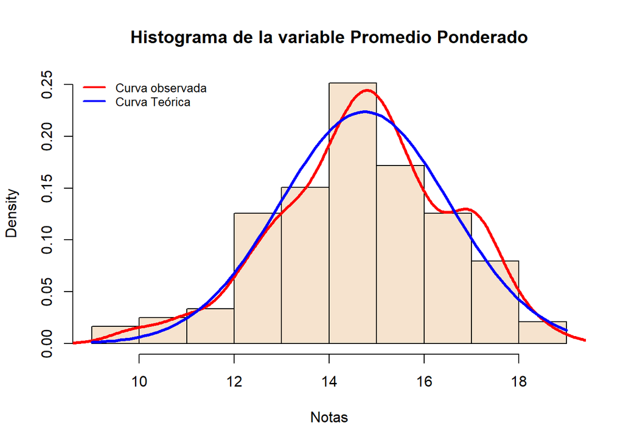

```r
hist(dfn$Promedio_Ponderado, freq=FALSE,main = "Histograma de la variable Promedio Ponderado", xlab="Notas",col = "#F6E3CE")
lines(density(dfn$Promedio_Ponderado,na.rm = TRUE),col="red",lwd=3)
curve(dnorm(x,mean = mean(dfn$Promedio_Ponderado,na.rm = TRUE),
            sd= sd(dfn$Promedio_Ponderado,na.rm = TRUE)),col="blue",lwd=3,add=T)

legend("topleft",c("Curva observada","Curva Teórica"),col=c("red","blue"),lty=1,lwd=2,bty="n",cex=0.8)
```

La curva observada indica la función de densidad del Promedio Ponderado, para ver si sigue un comportamiento normal, primero comprobamos y hallamos la verdadera normal con $\mu$ y $\sigma$ ya que con lo que tenemos son solo aproximaciones. Para hallar $\mu$ usamos la media que en este caso es 14.75 y para hallar $\sigma$ usamos la desviación estándar que en este caso sería 1.78 , creando así una nueva función llamada curva teórica, que viene a ser la función de la verdadera normal.

## 3.2 Descriptores Numéricos y gráficos - Horas en Promedio en las areas de estudio de la Universidad

Mediana y media con los rangos intercuartiles de la variable **horas promedio en la biblioteca**:

```
##    Min. 1st Qu.  Median    Mean 3rd Qu.    Max.    NA's
##   0.000   0.000   2.000   4.916   6.000  35.000       1
```

Mediana y media con los rangos intercuartiles de la variable **horas promedio en el piso 6**:

```
##    Min. 1st Qu.  Median    Mean 3rd Qu.    Max.    NA's
##   0.000   1.000   3.000   4.667   6.000  21.000       1
```

Mediana y media con los rangos intercuartiles de la variable **horas promedio en el piso 1**:

```
##    Min. 1st Qu.  Median    Mean 3rd Qu.    Max.    NA's
##   0.000   0.000   2.000   5.313   6.000  30.000       1
```

**Gráfico de caja de las horas en las áreas de estudio en la Universidad**

- En las tres tablas se muestra que la media o promedio tiene una diferencia considerable con respecto a la mediana, esto puede ser producto de datos atípicos, ya que la mediana es mas robusta que la media. Esta hipótesis se podrá apreciar en el gráfico a continuación.

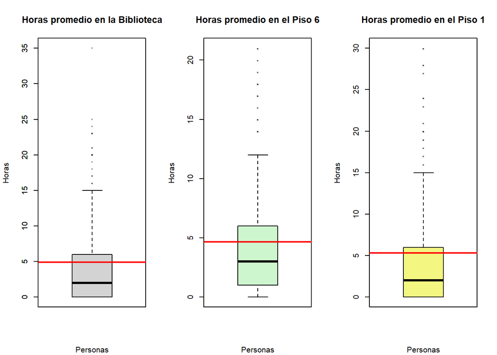

```r
op=par(mfrow=c(1,3))
boxplot(dfn$Hora_prom_Biblioteca,ylab="Horas",main="Horas promedio en la Biblioteca",sub="Personas",pch=20,border=rgb(0,0,0,0.2))
boxplot(dfn$Hora_prom_Biblioteca,outline=FALSE,add=TRUE,ylim=c(0,max(dfn$Hora_prom_Biblioteca)))
abline(h=mean(dfn$Hora_prom_Biblioteca, na.rm=TRUE),col="red",lwd=2)

boxplot(dfn$Hora_prom_piso6,ylab="Horas",main="Horas promedio en el Piso 6",sub="Personas",pch="*", col="#CEF6CE")
abline(h=mean(dfn$Hora_prom_piso6, na.rm=TRUE),col="red",lwd=2)

boxplot(dfn$Hora_prom_Piso1,ylab="Horas",main="Horas promedio en el Piso 1",sub="Personas",pch="*", col="#F3F781")
abline(h=mean(dfn$Hora_prom_Piso1, na.rm=TRUE),col="red",lwd=2)
```

```r
par(op)
```

- De acuerdo al diagrama de cajas podemos observar que el promedio de horas de las personas encuestadas para las diferentes zonas de estudio son muy cercanas a 5 horas.

## 3.3 Relación entre Espacio de estudio habitual vs Sexo

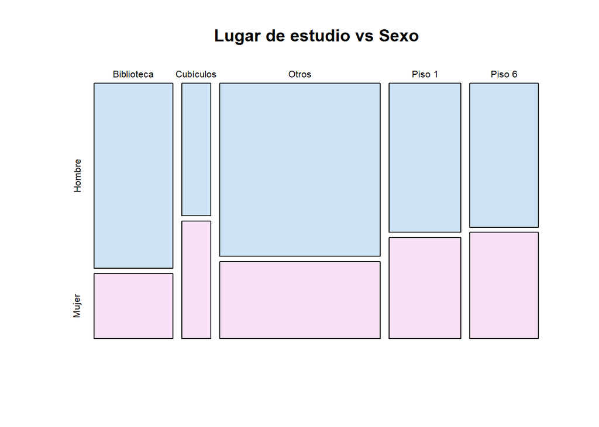

```r
mosaicplot(table(dfn$EspacioEst_habitual,dfn$Sexo),main="Lugar de estudio vs Sexo",col=c("#CEE3F6", "#F8E0F7"))
```

Se pueden observar dos tendencias:

1. La gran mayoría de encuestados corresponden a un sexo masculino.
2. La gran mayoría de personas suelen usar otros sitios dentro de la universidad para sus actividades. Además, los cubículos son los menos usados por las personas encuestadas.

Estas conclusiones nos servirá para un posterior análisis acerca de las razones por las que los estudiantes prefieren otros sitios dentro de la institución a los sitios de estudios que brinda la universidad.

## 3.4 Relación entre Hora promedio en Zonas de estudio vs Distrito

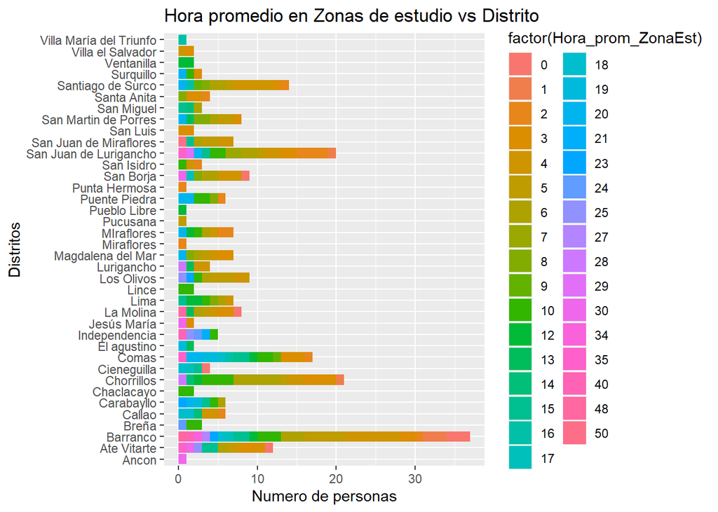

```r
ggplot(data=dfn,aes(factor(Distrito),fill=factor(Hora_prom_ZonaEst)))+ geom_bar(position = 'stack',stat='count') + coord_flip() +ylab("Numero de personas")+xlab("Distritos") +labs(title = "Hora promedio en Zonas de estudio vs Distrito")
```

Se puede apreciar en el siguiente gráfico que tanto las personas que viven muy lejos de Barranco como los que viven muy cerca de este, son en la mayoría las no paran un tiempo relativamente alto en la universidad. Por otra parte, se puede apreciar que hay una minoría de personas que utilizan las zonas de estudio por una minoría de tiempo durante la semana.

## 3.5 Relación entre Carreras vs Horas promedio en la Biblioteca

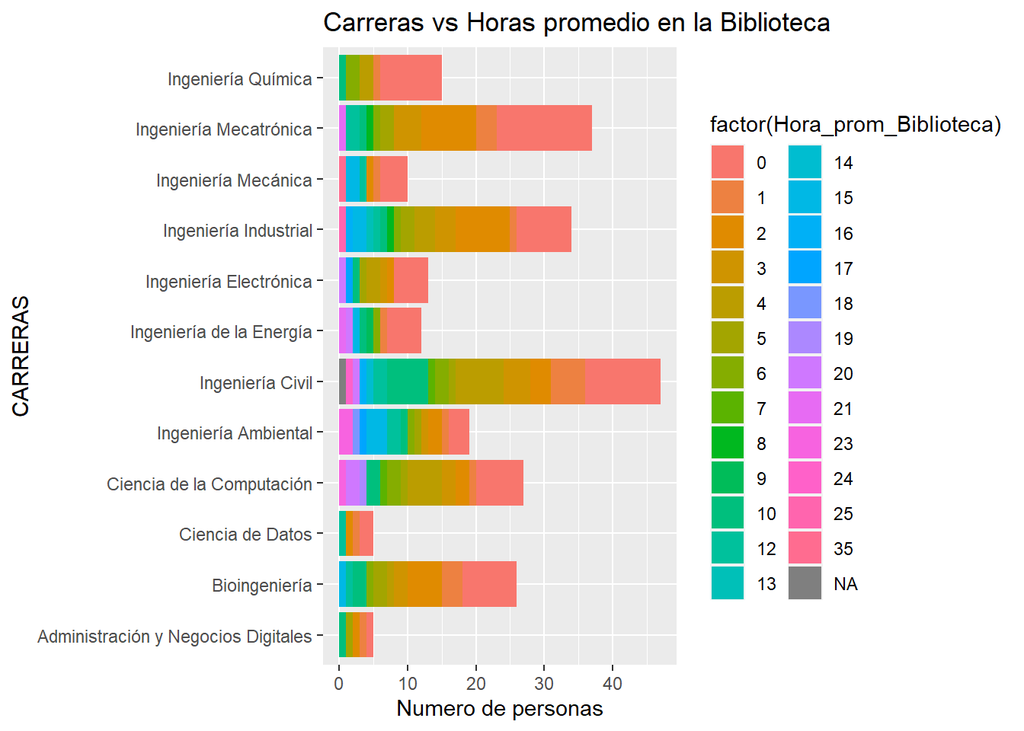

```r
ggplot(data=dfn,aes(factor(Carrera),fill=factor(Hora_prom_Biblioteca)))+ geom_bar(position = 'stack',stat='count') + coord_flip() +ylab("Numero de personas")+xlab("CARRERAS") +labs(title = "Carreras vs Horas promedio en la Biblioteca")
```

Según el gráfico de barras apiladas se puede observar que la gran mayoría de personas encuestadas son de la carrera de Ingeniería Civil. La gran mayoría de estos, pasan más tiempo en la biblioteca. Sin embargo, dentro de la gráfica se también se pudo identificar que de las personas encuestadas, la minoría son de las carreras de ingeniería mecánica, ciencia de lo datos; y administración y negocios digitales, de los cuales la mayoría si pasan tiempo en la biblioteca.

Se vera si hay una relación entre estas dos variables, una categórica y numérica.

Utilizaremos el boxplot con ancho variable para detectar aquellas técnicas de estudio con pocas observaciones y analizarlas con mayor cuidado.

[figure not shown]

```r
plot(dfn$Hora_prom_ZonaEst~dfn$Ciclo,col=c("#F7BE81","#F2F5A9","#D0F5A9","#A9F5A9","#A9F5D0","#A9F5F2","#A9D0F5","#D0A9F5","#F5A9F2","#F78181"),xlab="Ciclo",ylab="Hora promedio en zonas de estudio", varwidth=TRUE,main="Ciclo vs Horas promedio en la Biblioteca")
```

Se puede apreciar que hay una variabilidad en algunos ciclos, en el caso de la anchura, esto puede ser por la cantidad de observaciones que obtuvimos. Veamos si esto es cierto.

```r
table(dfn$Ciclo)
```

```
##
##  1º  2º  3º  4º  5º  6º  7º  8º  9º 10º
##  11  48  51  39  28  32  14  16   5   6
```

Se puede apreciar que de los encuestados, sólo hay 5 y 6 personas en los ciclos 9 y 10 respectivamente, por lo tanto, el rango intercuartil se puede mover fácilmente cambiando cualquiera de los 2 valores.

Por otro lado, se encontraron más datos atípicos o personas que sobrepasan el tiempo promedio en las zonas de estudio en los primeros 4 ciclos de la universidad.

## 3.7 Relación entre Hora promedio en la universidad vs Hora promedio en zonas de estudio

Covarianza:

```
## [1] 103.7634
```

La covarianza nos indica si es directa o inversamente proporcional, y al ver que es positivo se sabe que al aumentar horas promedio en la Universidad, el número de horas promedio en la zona de estudio aumentará, tienen relación directa positiva.

Correlación:

```
## [1] 60.00312
```

La correlación entre entre Horas promedio en la Universidad y Horas promedio en Zonas de estudio es de 60%, el grado de asociación es moderada.

Se añadió color sobre la opinión que tienen sobre si el estudio afecta positiva o negativamente en sus notas. Obteniendo el siguiente gráfico:

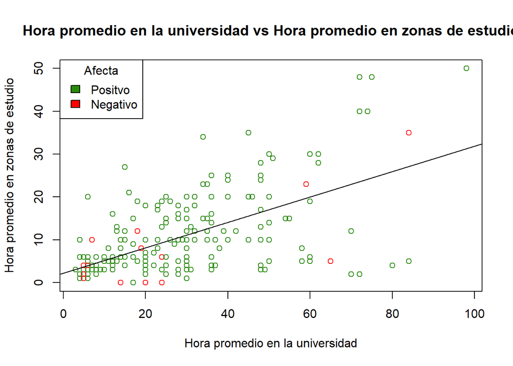

```r
plot(dfn$Hora_prom_Uni,dfn$Hora_prom_ZonaEst,xlab="Hora promedio en la universidad",ylab = "Hora promedio en zonas de estudio",col=ifelse(dfn$Afecta_Posi_Nega=="Positivamente","#298A08","red"),title("Hora promedio en la universidad vs Hora promedio en zonas de estudio"))
abline(lm(dfn$Hora_prom_ZonaEst ~ dfn$Hora_prom_Uni), col="black")#Gráfica la linea de la función
legend(x = "topleft", legend = c("Positvo","Negativo"), fill = c("#298A08", "Red"), title = "Afecta")
```

- Observamos en la gráfica que son muy pocos alumnos los que opinan que afecta negativamente las horas que pasan en la universidad en zonas de estudio.

## 3.8 Relación entre Lugar de estudio vs Uso del lugar de estudio

Para nuestro gráfico, como se quiere saber el uso académico especifico de las zonas de estudio dentro de la universidad, no tomaremos en cuenta la opción de todos en la variable Uso de lugar de estudio, por ser muy general. Obteniendo la siguiente gráfica:

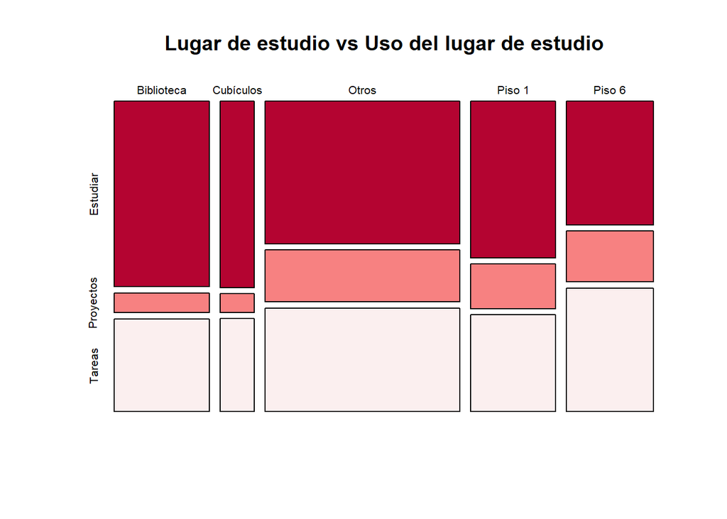

```r
dfn_1<-dfn
dfn_1$Uso_Lugar_Estudio[dfn_1$Uso_Lugar_Estudio == "Todos"]<- NA
mosaicplot(table(dfn$EspacioEst_habitual,dfn_1$Uso_Lugar_Estudio), main="Lugar de estudio vs Uso del lugar de estudio",col=c("#B40431", "#F78181", "#FBEFEF"))
```

```r
#table(dfn_1$Uso_Lugar_Estudio,dfn$EspacioEst_habitual)
```

- Como se ve la gráfica los alumnos usan los lugares de estudio para reforzar sus conocimientos y aprender más.
- Hay más alumnos que usan otro lugar de estudio dentro de la universidad que no son habituales para avanzar proyectos, hacer tareas y estudiar.
- Los alumnos que tiene acceso a los cubículos mayormente van para estudiar
- En el Piso 6 hay la misma cantidad de alumnos que van a estudiar y hacer tareas.

## 3.9 Relación entre Hora promedio en zonas de estudio vs Hora promedio en la universidad y agrupamos por ciclos

Para el análisis de dos variable numéricas optamos por un diagrama de dispersión, donde la relación en esta gráfica hicimos la función de la linea de correlación con Hora de promedio en la zona de estudio y Hora promedio en la universidad pero por ciclo, así tendremos una relación mas coherente.

Por la gráfica se puede observar que hay una fuerte correlación entre muchas variables

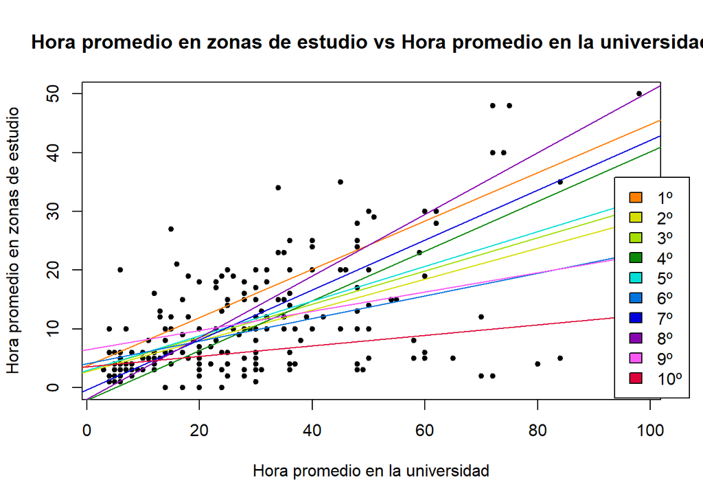

```r
dfn$Ciclo<-as.character(dfn$Ciclo)
plot(dfn$Hora_prom_Uni,dfn$Hora_prom_ZonaEst,pch=20,col="black",xlab="Hora promedio en la universidad",ylab = "Hora promedio en zonas de estudio",title("Hora promedio en zonas de estudio vs Hora promedio en la universidad"))

abline(lm(dfn$Hora_prom_ZonaEst[dfn$Ciclo=="1º"] ~ dfn$Hora_prom_Uni[dfn$Ciclo=="1º"]), col="#FF8000")#Gráfica la linea de la función
abline(lm(dfn$Hora_prom_ZonaEst[dfn$Ciclo=="2º"] ~ dfn$Hora_prom_Uni[dfn$Ciclo=="2º"]), col="#D7DF01")
abline(lm(dfn$Hora_prom_ZonaEst[dfn$Ciclo=="3º"] ~ dfn$Hora_prom_Uni[dfn$Ciclo=="3º"]), col="#A5DF00")
abline(lm(dfn$Hora_prom_ZonaEst[dfn$Ciclo=="4º"] ~ dfn$Hora_prom_Uni[dfn$Ciclo=="4º"]), col="#088A08")
abline(lm(dfn$Hora_prom_ZonaEst[dfn$Ciclo=="5º"] ~ dfn$Hora_prom_Uni[dfn$Ciclo=="5º"]), col="#01DFD7")
abline(lm(dfn$Hora_prom_ZonaEst[dfn$Ciclo=="6º"] ~ dfn$Hora_prom_Uni[dfn$Ciclo=="6º"]), col="#0174DF")
abline(lm(dfn$Hora_prom_ZonaEst[dfn$Ciclo=="7º"] ~ dfn$Hora_prom_Uni[dfn$Ciclo=="7º"]), col="#0101DF")
abline(lm(dfn$Hora_prom_ZonaEst[dfn$Ciclo=="8º"] ~ dfn$Hora_prom_Uni[dfn$Ciclo=="8º"]), col="#8904B1")
abline(lm(dfn$Hora_prom_ZonaEst[dfn$Ciclo=="9º"] ~ dfn$Hora_prom_Uni[dfn$Ciclo=="9º"]), col="#FA58F4")
abline(lm(dfn$Hora_prom_ZonaEst[dfn$Ciclo=="10º"] ~ dfn$Hora_prom_Uni[dfn$Ciclo=="10º"]), col="#DF013A")

legend(x = "topright",
       inset = c(-0.05, 0.3),
       legend = c("1º", "2º", "3º", "4º", "5º", "6º", "7º", "8º", "9º", "10º"),
       fill = c("#FF8000","#D7DF01","#A5DF00","#088A08","#01DFD7","#0174DF","#0101DF","#8904B1","#FA58F4","#DF013A"),
       xpd = TRUE)
```

- Se puede apreciar la mayor correlación en el ciclo 8 y la menor es del ciclo 10, es decir, no se podría confirmar que un alumno del ciclo 10 que pase más en la universidad necesariamente, pase mas tiempo en las zonas de estudio.

## 3.10 Relación entre Promedio ponderado vs Horas promedio en las zonas de estudio de la universidad

**Promedio Ponderado vs Horas promedio en la Biblioteca**

Covarianza:

```r
cov(dfn$Promedio_Ponderado,dfn$Hora_prom_Biblioteca, use='complete.obs')
```

```
## [1] -0.373561
```

Correlación:

```r
cor(dfn$Promedio_Ponderado,dfn$Hora_prom_Biblioteca, use='complete.obs')
```

```
## [1] -0.03319942
```

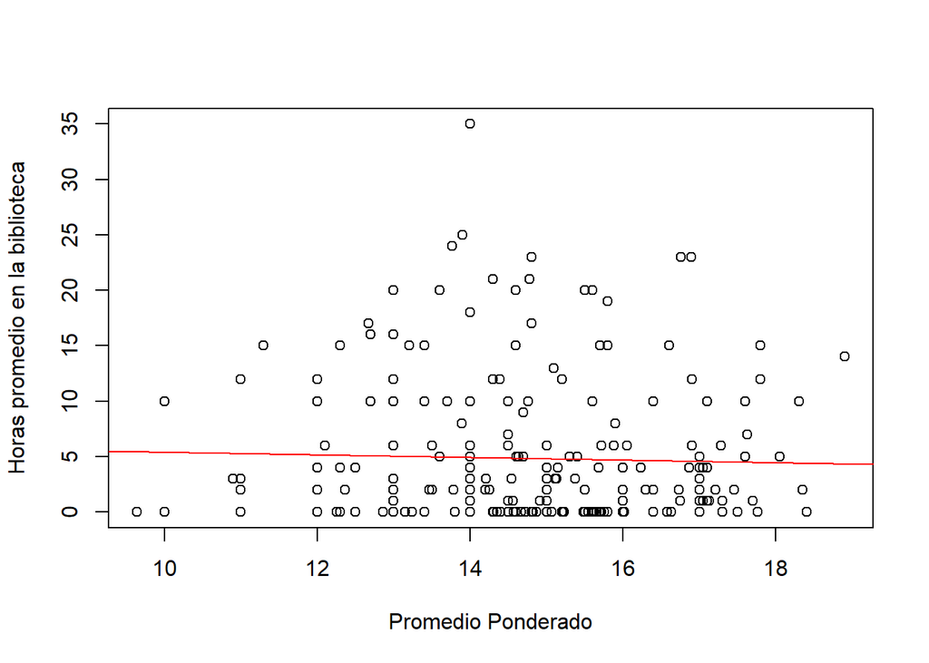

```r
plot(dfn$Promedio_Ponderado,dfn$Hora_prom_Biblioteca,xlab="Promedio Ponderado",ylab = "Horas promedio en la biblioteca")
abline(lm(dfn$Hora_prom_Biblioteca ~ dfn$Promedio_Ponderado), col="red")#Gráfica la linea de la función
```

**Promedio Ponderado vs Horas promedio en el piso 6**

Covarianza:

```r
cov(dfn$Promedio_Ponderado,dfn$Hora_prom_piso6, use='complete.obs')
```

```
## [1] 0.1828899
```

Correlación:

```r
cor(dfn$Promedio_Ponderado,dfn$Hora_prom_piso6, use='complete.obs')
```

```
## [1] 0.02086836
```

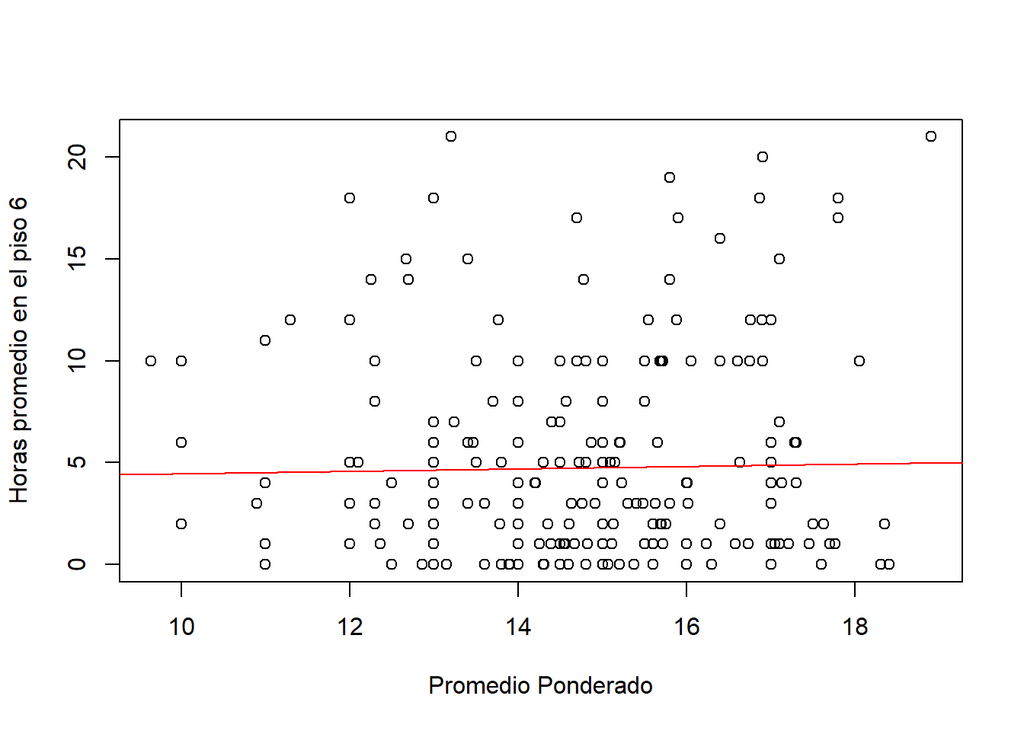

```r
plot(dfn$Promedio_Ponderado,dfn$Hora_prom_piso6,xlab="Promedio Ponderado",ylab = "Horas promedio en el piso 6")
abline(lm(dfn$Hora_prom_piso6 ~ dfn$Promedio_Ponderado), col="red")#Gráfica la linea de la función
```

**Promedio Ponderado vs Horas promedio en el piso 1**

Covarianza:

```r
cov(dfn$Promedio_Ponderado,dfn$Hora_prom_Piso1, use='complete.obs')
```

```
## [1] 0.3250137
```

Correlación:

```r
cor(dfn$Promedio_Ponderado,dfn$Hora_prom_Piso1, use='complete.obs')
```

```
## [1] 0.02595541
```

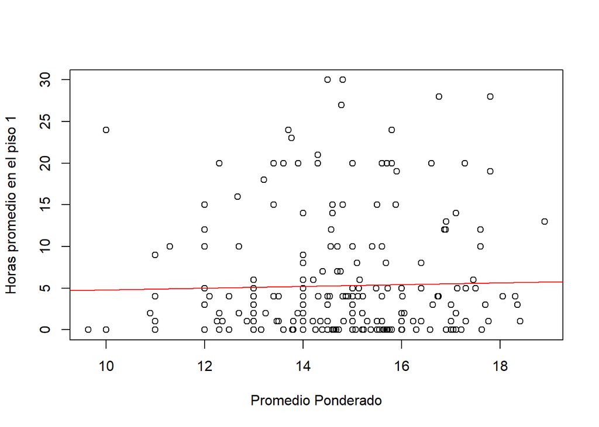

```r
plot(dfn$Promedio_Ponderado,dfn$Hora_prom_Piso1,xlab="Promedio Ponderado",ylab = "Horas promedio en el piso 1")
abline(lm(dfn$Hora_prom_Piso1 ~ dfn$Promedio_Ponderado), col="red")#Gráfica la linea de la función
```

- Como se ve en las tres gráfica se concluye que el modelo es malo debido al resultado de la recta de regresión lineal y por su bajo coeficiente de correlación, ya que sus datos están muy esparcidos y no siguen mucho la tendencia de la recta.

# 4 Análisis probabilístico

## 4.1 Análisis de promedio y horas de estudio promedio

Para el análisis de estás dos variables vamos a ver:

### 4.1.1 **¿Cuál es la probabilidad condicional de obtener un promedio mayor a la media dado que un estudiante estudió más que la media?**

Sea P el promedio y E las horas de estudio promedio de un estudiante, eliminando observaciones incompletas y posibles errores:

```r
Cond <- !is.na(dfn$Promedio_Ponderado) & dfn$Promedio_Ponderado != 0 & !is.na(dfn$Hora_prom_Est)
P <- dfn$Promedio_Ponderado[Cond]
E <- dfn$Hora_prom_Est[Cond]
n <- nrow(dfn[Cond, ])
```

Nota: Para que el cálculo de nuestras probabilidades tenga sentido, hemos tenido que filtrar las variables para considerar solo los casos en los que ambas variables están definidas

```r
MediaP <- mean(P)
MediaE <- mean(E)
MediaE
```

```
## [1] 13.36402
```

```r
MediaP
```

```
## [1] 14.74941
```

Utilizando la definición de probabilidad condicional, y teniendo en cuenta que nuestro experimento aleatorio consiste en sacar a una persona de un subconjunto de la muestra que satisface cierta condición en la que todos tienen la misma probabilidad de ser escogidos, podemos calcular esta probabilidad como sigue:

```r
(sum((P > MediaP) & (E > MediaE)) / n) / (sum(E > MediaE) / n)
```

```
## [1] 0.5108696
```

Por lo tanto, un estudiante que en promedio estudio mas que la media tendría un 51.09% de probabilidad de sacar un promedio ponderado mayor a la media de la encuesta.

### 4.1.2 **¿Cuál es la probabilidad condicional de obtener un promedio mayor a la media dado que un estudiante estudió menos o igual que la media?**

```r
((sum((P > MediaP) & (E <= MediaE)) / n) / (sum(E <= MediaE) / n))
```

```
## [1] 0.5238095
```

### 4.1.3 **¿Cuál es la probabilidad condicional de obtener un promedio menor a la media dado que un estudiante estudió mas o igual que la media?**

```r
((sum((P < MediaP) & (E >= MediaE)) / n) / (sum(E >= MediaE) / n))
```

```
## [1] 0.4891304
```

Es menos probable que un estudiante que estudia mas que la media saque un promedio ponderado menor a la media. Esto se puede ver en la pregunta anterior, donde consideramos que las horas de estudio no necesariamente influyen de manera directa al promedio.

## 4.2 Análisis de horas promedio en zonas de estudio y horas de estudio en la universidad

Sea P_Uni el promedio de las horas en la universidad y P_Ze el promedio de las horas en las zonas de estudio, eliminando observaciones incompletas y posibles errores:

```r
summary(dfn$Hora_prom_ZonaEst)
```

```
##    Min. 1st Qu.  Median    Mean 3rd Qu.    Max.
##    0.00    4.00    6.00   10.12   15.00   50.00
```

```r
Cond1 <- !is.na(dfn$Hora_prom_Uni) & dfn$Hora_prom_Uni != 0 & !is.na(dfn$Hora_prom_ZonaEst)
P_Uni <- dfn$Hora_prom_Uni[Cond]
P_Ze <- dfn$Hora_prom_ZonaEst[Cond]
n1 <- nrow(dfn[Cond, ])
```

Nota: Para que el cálculo de nuestras probabilidades tenga sentido, hemos tenido que filtrar las variables para considerar solo los casos en los que ambas variables están definidas

```r
MediaP_Uni <- mean(P_Uni)
MediaP_Ze <- mean(P_Ze)
MediaP_Uni
```

```
## [1] 27.18828
```

```r
MediaP_Ze
```

```
## [1] 10.12552
```

Al igual que antes, nuestro espacio es equiprobable, pues cada persona tiene la misma probabilidad de ser elegida en el subconjunto que satisface cierta condición que tomamos de la muestra.

Utilizando la definición de probabilidad condicional, y teniendo en cuenta que nuestro experimento aleatorio consiste en sacar a una persona de un subconjunto de la muestra que satisface cierta condición en la que todos tienen la misma probabilidad de ser escogidos, podemos calcular esta probabilidad como sigue:

```r
(sum((P_Uni > MediaP_Uni) & (P_Ze > MediaP_Ze)) / n1) / (sum(P_Ze > MediaP_Ze) / n1)
```

```
## [1] 0.7662338
```

### 4.2.2 **¿Cuál es la probabilidad condicional de saber si una persona que pasa menos tiempo promedio que la media en la universidad, pasa mas tiempo promedio que la media en las zonas de estudio?**

Esto lo podemos calcular con facilidad, utilizando el concepto del complemento, el cual seria el siguiente para nuestro caso:

Ahora, procedemos a hallarlo:

```r
1-((sum((P_Uni > MediaP_Uni) & (P_Ze > MediaP_Ze)) / n1) / (sum(P_Ze > MediaP_Ze) / n1))
```

```
## [1] 0.2337662
```

## 4.3 Modelo Hipergeometrico - Variable aleatoria discreta

Para este caso hemos elegido una variable categórica nominal, lugar habitual de estudio dentro de la universidad. Se tiene que tomar en cuenta que hay 46 estudiantes que habitúan la biblioteca, 17 cubículos, 42 piso 1, 43 piso 6; y 94 otros lugares dentro de la universidad.

```r
table(dfn$EspacioEst_habitual)
```

```
##
## Biblioteca  Cubículos      Otros     Piso 1     Piso 6
##         46         17         94         42         43
```

Donde:

M: Cantidad de elementos que cumplen una característica deseada N: Tamaño de la población xo: Cantidad de éxitos n: Tamaño de la muestra

```r
M<-table(dfn$EspacioEst_habitual)
dhyper(10, 42, 242 - 42, 50)
```

```
## [1] 0.1372869
```

$ Exp(x) = n.p$

```r
E<-50*(42/242)
E
```

```
## [1] 8.677686
```